# Social Networks - Week 3

Alexander Noll

Oktober 2015

```r
set.seed(1)
library(statnet)
library(igraph)
library(boot)
library(dplyr)
library(magrittr)
setwd("~/Desktop/Networks/Social_Networks")
data(florentine)
```

In this document, we solve the homework problems for week 3 of the Coursera course “Social and Economic Networks”. The data is in the statnet package. We plot the network here.

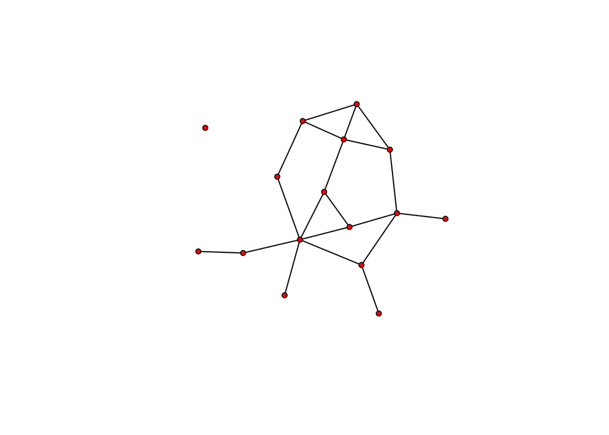

```r
plot(flomarriage)
```

# Erdody-Renyi graph

Firstly, we fit an Erdoy-Renyi random graph. This is the special case of an exponential random graph model that fits only the number links (i.e. the counting statistics entering the exponential random graph model is only the number of edges in the graph).

```r
florentine_edges <- ergm(flomarriage ~ edges)
```

We inspect the coefficients:

```r
florentine_edges
```

```
##
## MLE Coefficients:
##  edges
## -1.609
```

Recall that for these kinds of ERGS, we have a logistic regression model, i.e. $log(\frac{p}{1 - p} = \beta$), where $\beta$ is the coefficient of the above model. Thus, we have

```r
p <- inv.logit(florentine_edges$coef)
p
```

```
##     edges
## 0.1666667
```

# Links and triangles

```r
coef_estimate
```

[output not shown]

```
## [1] 0.1514241
```

# Small Worlds Model

In this second part, we will have a look at the small worlds model discussed in Week 2 of the course. We firstly load the data

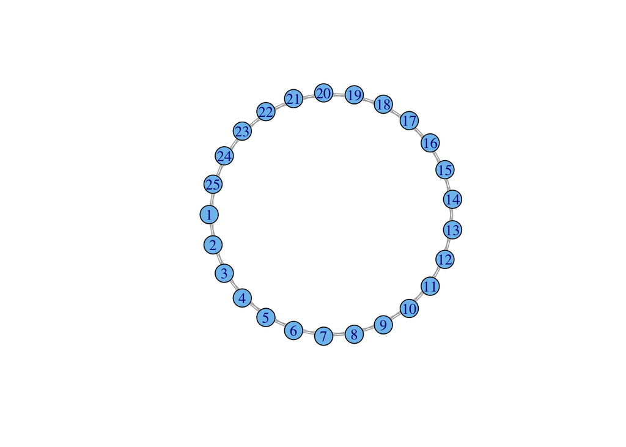

```r
small_worlds <- read.graph(file = "Ring25.NET", format = "pajek")
plot(small_worlds)
```

From the plot, we actually see the parameter; it is clearly $6$, since we can hop two steps to the left or to the right from any vertex. We can, however, also calculate it:

```r
diameter(small_worlds)
```

```
## [1] 6
```

For the clustering coefficient, we get:

```r
transitivity(small_worlds)
```

```
## [1] 0.5
```

This can also be calculated manually easily. By symmetry, it suffices to calculate the clustering coefficient for a single node. Let us pick the node 1. THis has connection to 2, 3, 24, 25. Thus, there are 6 possible triangles, and three of them are formed.

Now, we add a couple of links to the ring:

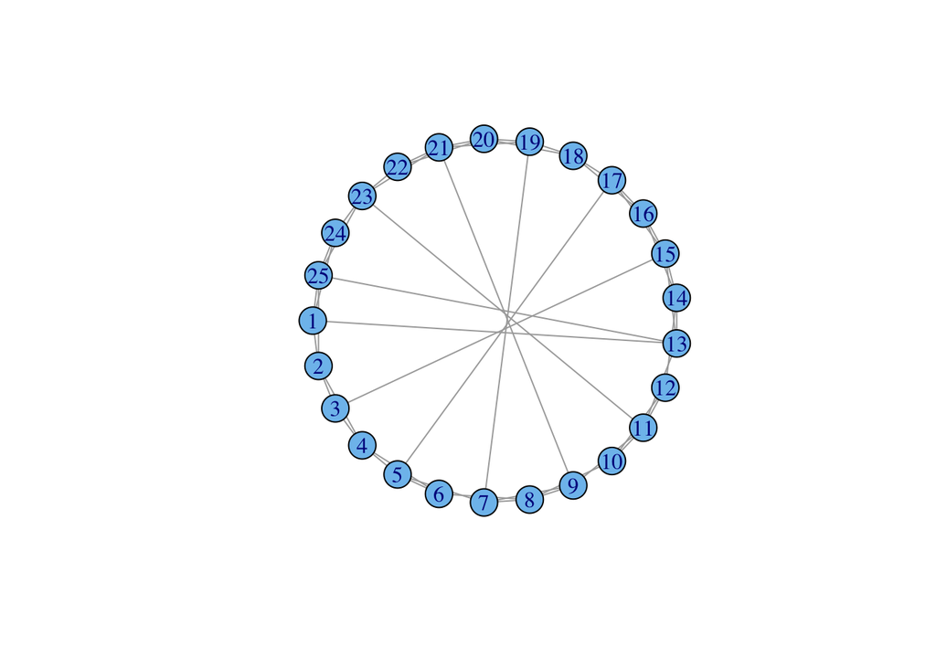

```r
edges_to_delete <-
    data.frame(
        from = c(3, 5, 7, 10, 13, 19, 24),
        to = c(1, 3, 6, 9, 12, 17, 22)
    )

small_worlds %<>%
    add.edges(c(1, 13)) %>%
    add.edges(c(3, 15)) %>%
    add.edges(c(5, 17)) %>%
    add.edges(c(7, 19)) %>%
    add.edges(c(9, 21)) %>%
    add.edges(c(11, 23)) %>%
    add.edges(c(13, 25))

for(row in 1:nrow(edges_to_delete)){
    small_worlds[edges_to_delete[row , 1], edges_to_delete[row , 2]] <- FALSE
}

plot(small_worlds)
```

Now, we calculate the diameter and average clustering coefficient:

```r
diameter(small_worlds, directed = FALSE, weights = NA)
```

```
## [1] 4
```

```r
transitivity(small_worlds, type = "local") %>% mean
```

```
## [1] 0.3333333
```

```r
Sys.Date()
```

```
## [1] "2015-10-11"
```